# Vaxpack: Fast and Efficient Population Genetic Analysis Gadget

Elijah Martin, Myo Naung

January, 2019

## Introduction

Extensive use of sequencing technology to solve population related biological problems demands efficient, and comphrehensive tools for data analyses. Different software packages for population genetics/genomics such as PopGenome, R package (Pfeifer, B. et al 2014) necessitate the basic knowledge of command line tools. Programs with the graphical user interface such as DnaSP require extensive pre-processing and post-processing of the data. Here, **vaxpack** is a powerful user-friendly R package for fast, easy and comphrehensive analyses of population genomic/genetic data for a gene of interest of haploid organisms. It is designed for biologists with minimal command line tool knowledge. **vaxpack** includes a wide range of polymorphism and population genetic diversity metrics, automatic translation of input DNA sequences into the amino acid sequences, automatic visualization of output on ggplot2, diversity and neutrality statistics with users’ defined minor haplotype/ allele frequency thresholds, as well as users’ defined sliding scale options. In addition, the output can be saved in users’ defined formats for further manipulations, and analyses. Graphical outputs are automatically labelled, and are ready to use.

The following sections explain how to use the vaxpack R package.

## Installing vaxpack

The package can be installed directly from the Github using **githubinstall()** function from the **githubinstall package** using the packagename. vaxpack is built for R (>= 3.1.0). See more about helpful ways to install R packages from Github [here](https://cran.r-project.org/web/packages/githubinstall/vignettes/githubinstall.html).

```r
install.packages("githubinstall")
library(githubinstall)
githubinstall("vaxpack")
library(vaxpack)
```

## Loading Data

In the meantime, vaxpack only accepts aligned genomic (DNA) sequences of the same length in “.fasta”, “.fas”, “.fa”, and “.seq” extensions as input. Therefore, preprocessing of input data is required. Flexible input formats such as from VCF will be included in the future release. Coding sequences without introns are expected for accurate translation of input into amino acids if the interest includes population genetic analyses of amino acid sequences.

The input data has to be inside a folder similar to **readData()** from PopGenome package. If the analyses include more than one populations of the same gene/coding region, build different fasta files and put inside a folder. For example,

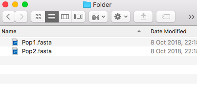

*The input folder shown here includes two .fasta files from two populations*

**vaxpack_input()** is an all in one function for conducting population genetic analyses. It uses a prompt/response method for input, and needs the following

1. A file path to a folder containing aligned DNA fasta files to be analysed.
2. A file path to a reference in fasta format (not inside folder).
3. The name of the gene you are analysing for graphical purposes.

```r
> vaxpack_input()
The following analyses are intended for haploid organisms such as Plasmodium
For this function to work you will need:
1 - A folder containing all files to be analysed
     These need to be aligned, the same length, and with no gaps! (e.g. with MEGA)
     Only accepts bases 'A/a', 'T/t', 'C/c', 'G/g'
     Gaps, or bases that are not AaTtCcGg, are called as reference, so accuracy is lost
     These replacements will be counted in the results table as "invalid sites"

     Make a different file for different populations to compare them
     e.g. 'Asymptomatic.fasta, Symptomatic.fasta', or 'Brazil.fasta, Peru.fasta'

2 - A reference file for the gene you are analysing
     (This cannot be in the same folder as the other files!)

Accepted extensions are ".fasta", ".fas", ".fa", and ".seq"

Enter the file path to your folder with a "/" at the end
e.g. "/users/me/documents/r files/my fasta folder/"

 My folder path <-"/Users/Desktop/test_vaxpack/Fasta/"

  Enter the file path to your reference file
 e.g. "/users/me/documents/r files/reference.fasta"
 My ref .fasta file path <- "/Users/Desktop/test_vaxpack/reference CDS_.fasta"

 What is the name of the gene youre analysing ? <- genename

Completed! Step: 23 of 23
vaxpack_input() took 42 secs
Now use vaxpack_output() to get your results!
```

Normally, input files of 2kb gene from 500 samples took less than one minute. Now, core calculation is done for vaxpack, and is ready for outputs. Bigger sample size and larger gene might take longer.

## Obtaining Output

Outputs can be instantly accessed via **vaxpack_output()** functions.

```r
vaxpack_output()

Choose your output:
TABLES
1  - Results Table
2  - Haplotype Table
3  - Minor Allele Frequency Table (Nucleotides)
4  - Minor Allele Frequency Table (Amino Acids)

GRAPHS
5  - Haplotype Population Pie Chart
6  - AA Variant Percentage Column Graph
7  - Phylogenetic Tree
8  - Haplotype Accumulation Plot

SLIDING SCALE
9  - Polymorphism
10 - Tajimas D
11 - Nucleotide Diversity
12 - All Sliding Scale Graphs Overlapped

13 - Sliding Scale data table

Enter a number from the selection above - 1
```

Specific output from above can be chosen easily. If option - 1: Results Table is chosen, users can further manipulate threshold/cut-off of the specific parameter.For example,

```r
Minimal haplotypes will be calculated using only the segregation sites where polymorphism
is found in at least 'x' percent of the population at that site
'x' <-  1

Saved as "vp.RESULTS.TABLE", use write.csv() to save to excel
e.g. write.csv(vp.RESULTS.TABLE, file = "my.results.table.in.excel")
```

1 - **Results Table** gives us sample size, length of sequence, invalid sites, number of segregation size, number of single nucleotide polymorphisms (SNPs), average tajima’s D (Tajima, F, 1989), average nucleotide diversity (Nei & Li, 1979), number of total haplotype based on nucleotide, minimal haplotypes based on amino acid, and user defined cut-off points.

*If more than one population is included in the analyses, the following outputs use total of all input populations.*

2 - **Haplotype Table** gives the information for total haplotypes compositions according to their frequencies, and differences from the reference amino acid sequence. Haplotypes are listed in descending order of frequency, with Rank 1 representing the most common haplotype.

3 - **Minor Allele Frequency Table (Nucleotides)** gives us polymorphic sites, reference nucleotid at the site, and composition of minor and major allele frequencies.

4 - **Minor Allele Frequency Table (Amino Acids)** gives us polymorphic sites, reference amino acid at the site, and composition of minor and major allele frequencies.

5 - **Haplotype Population Pie Chart** displays distribution of haplotypes above a specific cut-off value. It is built using **plotly package**. The size of the fragment reflects the relative frequency of haplotype found in the population.

6 - **AA Variant Percentage Column Graph** displays publication-quality amino acid changes and positionsabove a specific user defined cut-off values.

7 - **Phylogenetic Tree** is calculated using unrooted, neighor joining (NJ) method using distance matrix and **ape package**. Different input populations will be labelled in different colors. See more information about ape package [here](http://ape-package.ird.fr/).

*Note: Bootstrapped values are not displayed in the tree in the meantime, but will be included in future releases.*

8 - **Haplotype Accumulation Plot** is calculated based on “rarefaction method” with 100 permutations using imported **specaccum()** function from the vegan package. For detail information about vegan package, [see here](https://cran.r-project.org/web/packages/vegan/index.html).

9 - **Polymorphism**, the publication-quality plot displays polymorphic sites across the gene of interest under users’ defined sliding window scale.

10 - **Tajima’s D**, the publication-quality plot displays Tajima’s D values across the gene of interest under users’ defined sliding window scale. p-values to test neutral theory of molecular evolution are determined by original computer simulation from Fumio Tajima on a variety of sample size following beta distrubution (Tajima, F, 1989).

11 - **Nucleotide Diversity**, the publication-quality plot displays nucleotide diversity values across the gene of interest under users’ defined sliding window scale.

12 - **All Sliding Scale Graphs Overlapped**, the overlapped plot for polymorphisms, nucleotide diversity, and Tajima’s D values. It is scaled to Tajima’s D values.

13 - **Sliding Scale data table**, table output for segregation sites, nucleotide diversity, tajima’s D under users’ defined sliding window scales.

## Additional Aspects

vaxpack can accept multiallelic positions. vaxpack accept SNP data formatted in fasta, but will not produce accurate statistical outputs. All genetic diversity metrics from vaxpack will be particularly useful for antigenic diversity study. Future release will expand to diploid organisms.

## Handling missing data (Gap and ambigious bases)

vaxpack currently only accepts bases ‘A/a’, ‘T/t’, ‘C/c’, ‘G/g’. Gaps or ambigious bases are set as reference, and they are documented as invalid sites.

## Session Info

```r
> sessionInfo()
R version 3.4.0 (2017-04-21)
Platform: x86_64-apple-darwin15.6.0 (64-bit)
Running under: OS X El Capitan 10.11.6

Matrix products: default
BLAS: /System/Library/Frameworks/Accelerate.framework/Versions/A/Frameworks/vecLib.framework/Versions/A/libBLAS.dylib
LAPACK: /Library/Frameworks/R.framework/Versions/3.4/Resources/lib/libRlapack.dylib

locale:
[1] en_GB.UTF-8/en_GB.UTF-8/en_GB.UTF-8/C/en_GB.UTF-8/en_GB.UTF-8

attached base packages:
[1] stats     graphics  grDevices utils     datasets  methods
[7] base

loaded via a namespace (and not attached):
[1] compiler_3.4.0 tools_3.4.0    yaml_2.2.0
```

## References

1. Gotellli, N.J. & Colwell, R.K. (2001). “Quantifying biodiversity: procedures and pitfalls in measurement and comparison of species richness”. Ecology Letters *4*, 379–391.
2. Nei, M.; Li, W. (1979). “Mathematical Model for Studying Genetic Variation in Terms of Restriction Endonucleases”. PNAS. 76 (10): 5269–73. doi:10.1073/pnas.76.10.5269. PMC 413122. PMID 291943.
3. Nei, M.; Tajima, F. (1981), “DNA polymorphism detectable by restriction endonucleases”, Genetics 97:145
4. Pfeifer, B. et al. (2014) “PopGenome: An Efficient Swiss Army Knife for Population Genomic Analyses in R”. Molecular Biology and Evolultion 31(7): 1929-1936.doi:10.1093/molbev/msu136
5. Tajima, F. (1989). “Statistical method for testing the neutral mutation hypothesis by DNA polymorphism”. Genetics. 123 (3): 585–95. PMC 1203831. PMID 2513255